# 07-mle-and-mm

Sriram Kannan

07-11-2021

#Introduction

Maximum likelihood (MLE) and method of moments (MM) are two common methods for constructing a model.This blog post will be a tutorial on how one might use Method of Moments and Maximum Likehood Estimation to model (a) Glycohemoglobin and (b) Height of adult females. The data will be from National Health and Nutrition Examination Survey 2009-2010 (NHANES), available from the Hmisc package. The two methods will be compared and contrasted as well as the choice of distribution.

#Methodology

```r
require(dplyr)
Hmisc::getHdata(nhgh)
d1 <- nhgh %>%
  filter(sex == "female") %>%
  filter(age >= 18) %>%
  select(gh, ht) %>%
  filter(1:n()<=1000)
```

We will be using the Gamma Distribution, Normal Distribution and the Weibull Distribution in this tutorial.

#Method of Moments All 3 distributions are 2 Parameter Distributions and we will be defining 2 Sample Moments for the Method of Moments for each of the attributes we’d like to model - i.e, Glycohemoglobin (gh) and Height of adult females(ht)

```r
xbargh = mean(d1$gh)
s2gh = var(d1$gh)
xbarht = mean(d1$ht)
s2ht = var(d1$ht)
```

Method of Moments - Gamma Distribution We solve a series of simultaneous equations to establish a relationship between the Population Moments to the Sample Moments.

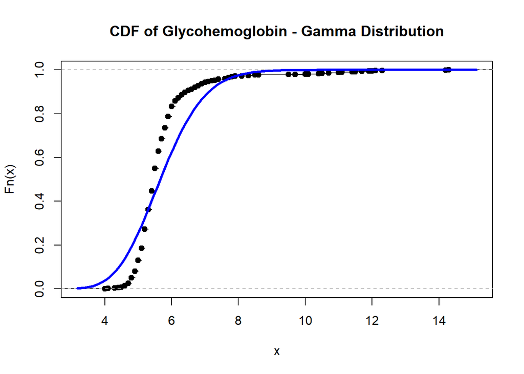

```r
shape_hatgh <- xbargh^2/s2gh
scale_hatgh <- s2gh/xbargh

shape_hatht <- xbarht^2/s2ht
scale_hatht <- s2ht/xbarht

Fghgamma <- function(x){
pgamma(x, shape = shape_hatgh, scale = scale_hatgh)
}

Fhtgamma <- function(x){
pgamma(x, shape = shape_hatht, scale = scale_hatht)
}

plot(ecdf(d1$gh), main = "CDF of Glycohemoglobin - Gamma Distribution")
curve(Fghgamma(x), add = TRUE, col = "blue", lwd = 3)
```

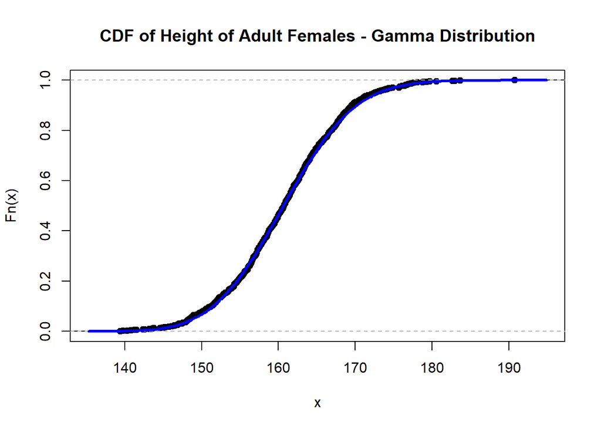

```r
plot(ecdf(d1$ht), main = "CDF of Height of Adult Females - Gamma Distribution")
curve(Fhtgamma(x), add = TRUE, col = "blue", lwd = 3)
```

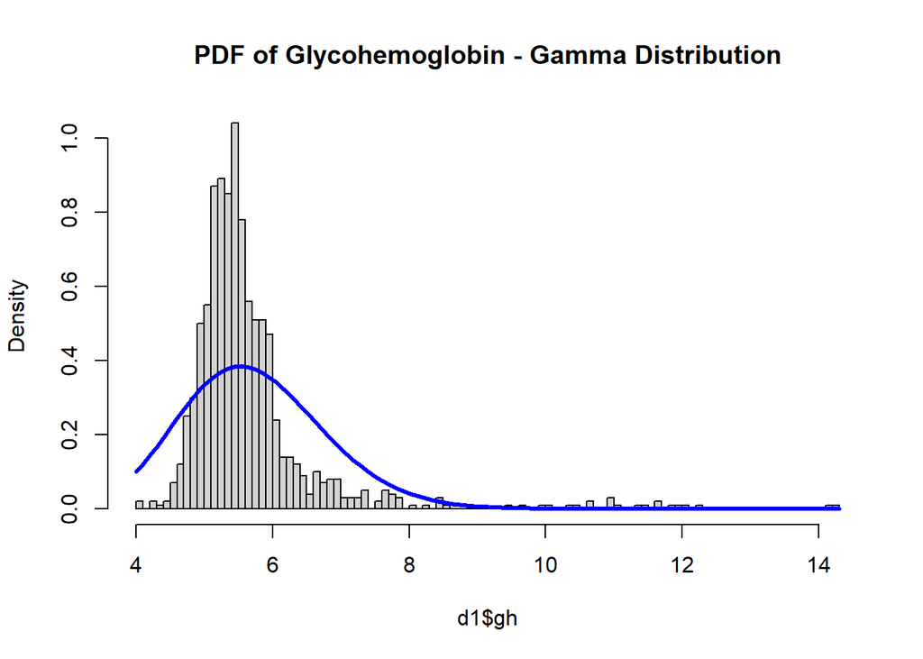

```r
fghgamma <- function(x){dgamma(x, shape = shape_hatgh, scale = scale_hatgh)}
fhtgamma <- function(x){dgamma(x, shape = shape_hatht, scale = scale_hatht)}

hist(d1$gh, breaks = 100, freq = FALSE, main = "PDF of Glycohemoglobin - Gamma Distribution")
curve(fghgamma(x), add = TRUE, col = "blue", lwd = 3)
```

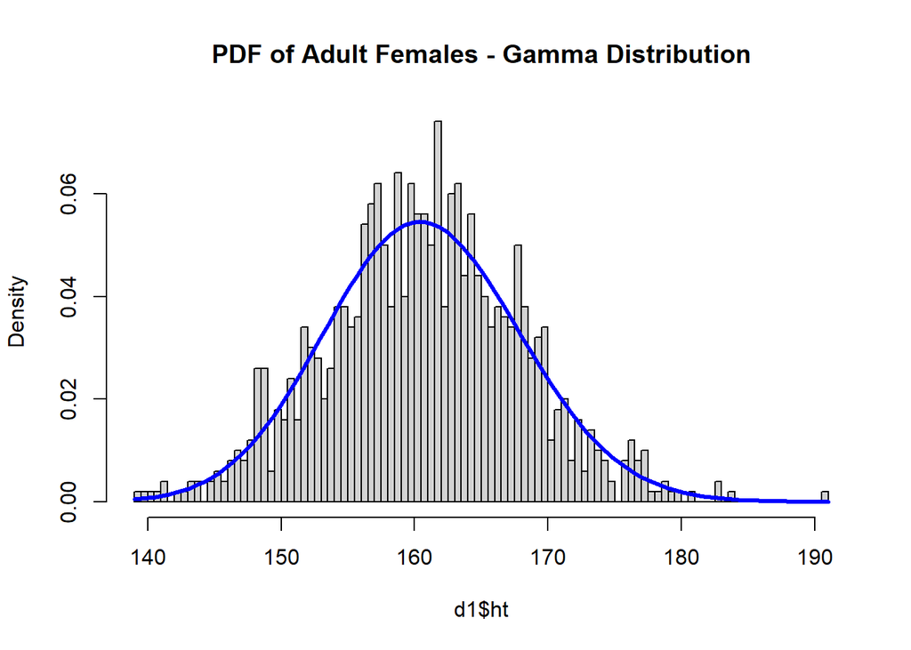

```r
hist(d1$ht, breaks = 100, freq = FALSE, main = "PDF of Adult Females - Gamma Distribution")
curve(fhtgamma(x), add = TRUE, col = "blue", lwd = 3)
```

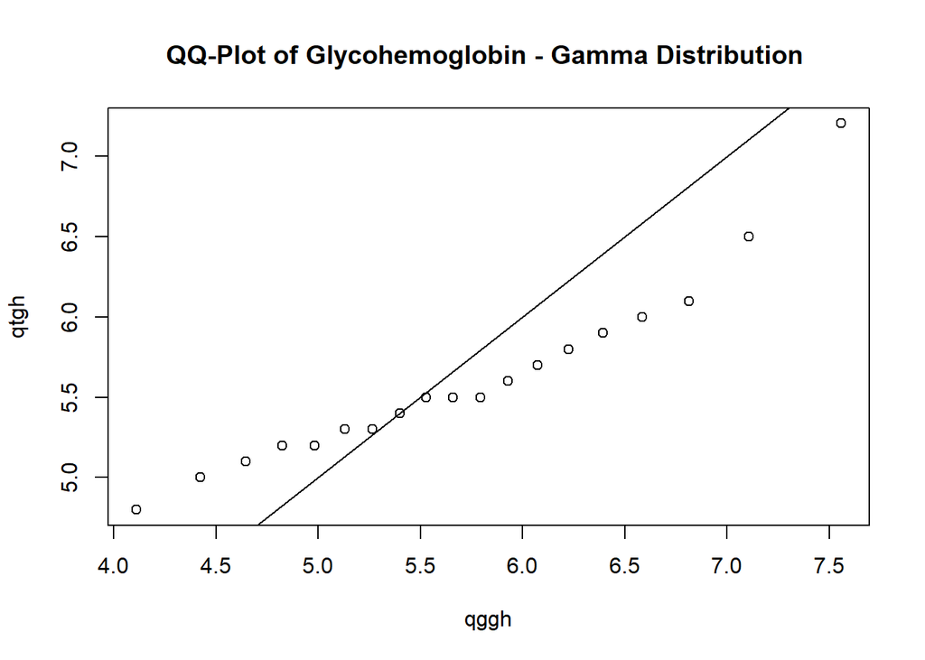

```r
sq <- seq(0.05,0.95,by=0.05)
qtgh <- quantile(d1$gh, sq)
qtht <- quantile(d1$ht, sq)
qggh <- qgamma(sq, shape = shape_hatgh, scale = scale_hatgh)
qght <- qgamma(sq, shape = shape_hatht, scale = scale_hatht)
plot(qggh,qtgh, main="QQ-Plot of Glycohemoglobin - Gamma Distribution ")
abline(0,1)
```

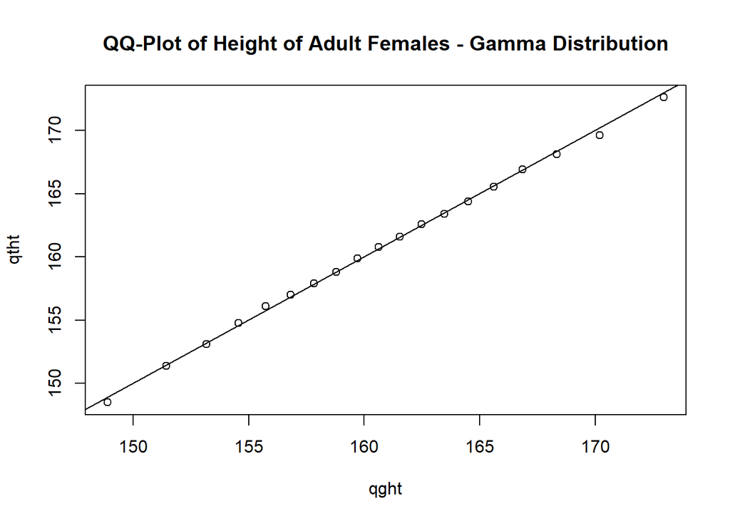

```r
plot(qght,qtht, main="QQ-Plot of Height of Adult Females - Gamma Distribution")
abline(0,1)
```

```r
#Outputs of Estimated Parameters
shape_hatgh
```

```
## [1] 29.59754
```

```r
scale_hatgh
```

```
## [1] 0.1934147
```

```r
shape_hatht
```

```
## [1] 482.1886
```

```r
scale_hatht
```

```
## [1] 0.333359
```

Method of Moments using Gamma Distribution seems to be a reasonable fit for the Height of Adult Females data as per both the generated CDF closely matching the ecdf as well as the generated PDF closely matching the histogram. The Glycohemoglobin data on the other hand seems to be a poor match for the Gamma Distribution due to sigificant variation of the generated CDF from the ecdf as well as a massive variation in the generated PDF where it fails to capture the peaks of the data. The QQ plot using the Gamma Distribution seems to be a great fit for Height of Adult Females data but a poor fit for the Glycohemoglobin data.

Method of Moments - Normal Distribution

In the Normal Distribution, since it’s standardized, the Population Moments are equal to the sample moments.

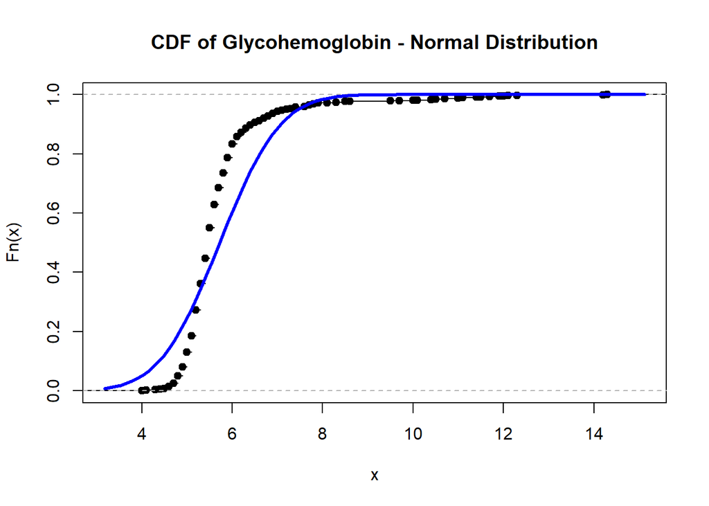

```r
meangh <- xbargh
stdgh <- sqrt(s2gh)

meanht <- xbarht
stdht <- sqrt(s2ht)

Fghnorm <- function(x){
pnorm(x, mean = meangh, sd = stdgh)
}

Fhtnorm <- function(x){
pnorm(x, mean = meanht, sd = stdht)
}

plot(ecdf(d1$gh), main = "CDF of Glycohemoglobin - Normal Distribution")
curve(Fghnorm(x), add = TRUE, col = "blue", lwd = 3)
```

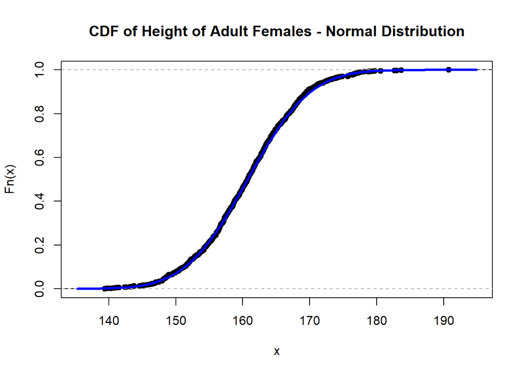

```r
plot(ecdf(d1$ht), main = "CDF of Height of Adult Females - Normal Distribution")
curve(Fhtnorm(x), add = TRUE, col = "blue", lwd = 3)
```

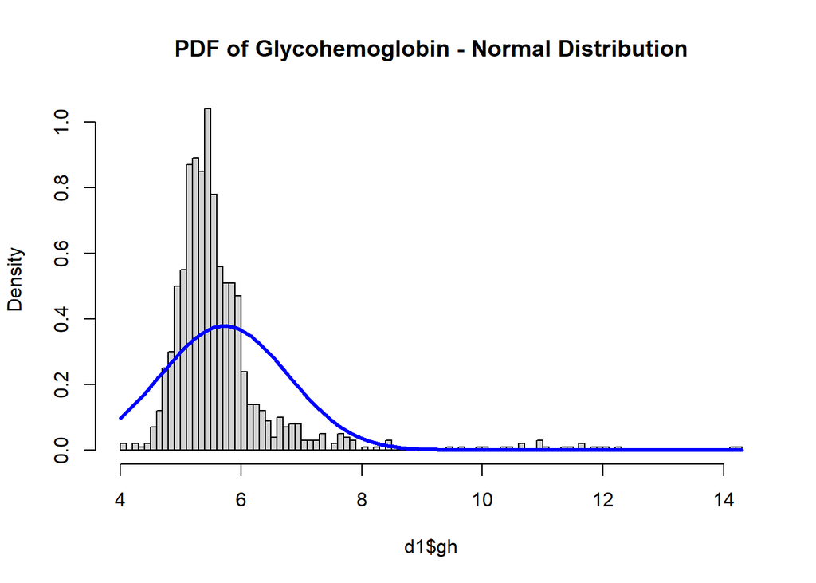

```r
fghnorm <- function(x){dnorm(x, mean = meangh, sd = stdgh)}
fhtnorm <- function(x){dnorm(x, mean = meanht, sd = stdht)}

hist(d1$gh, breaks = 100, freq = FALSE, main = "PDF of Glycohemoglobin - Normal Distribution")
curve(fghnorm(x), add = TRUE, col = "blue", lwd = 3)
```

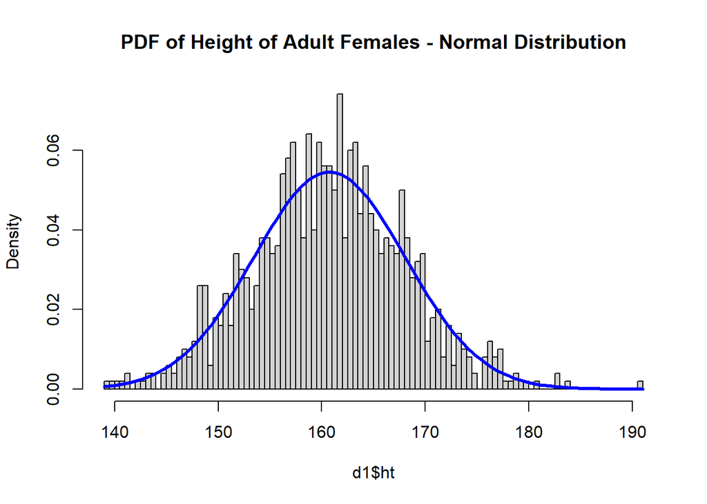

```r
hist(d1$ht, breaks = 100, freq = FALSE, main = "PDF of Height of Adult Females - Normal Distribution")
curve(fhtnorm(x), add = TRUE, col = "blue", lwd = 3)
```

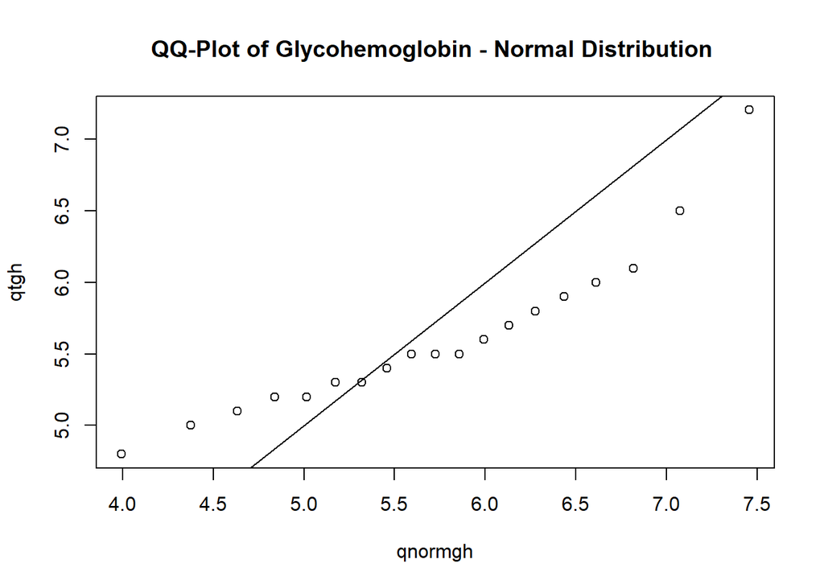

```r
qnormgh <- qnorm(sq, mean = meangh, sd = stdgh)
qnormht <- qnorm(sq, mean = meanht, sd = stdht)
plot(qnormgh,qtgh, main="QQ-Plot of Glycohemoglobin - Normal Distribution ")
abline(0,1)
```

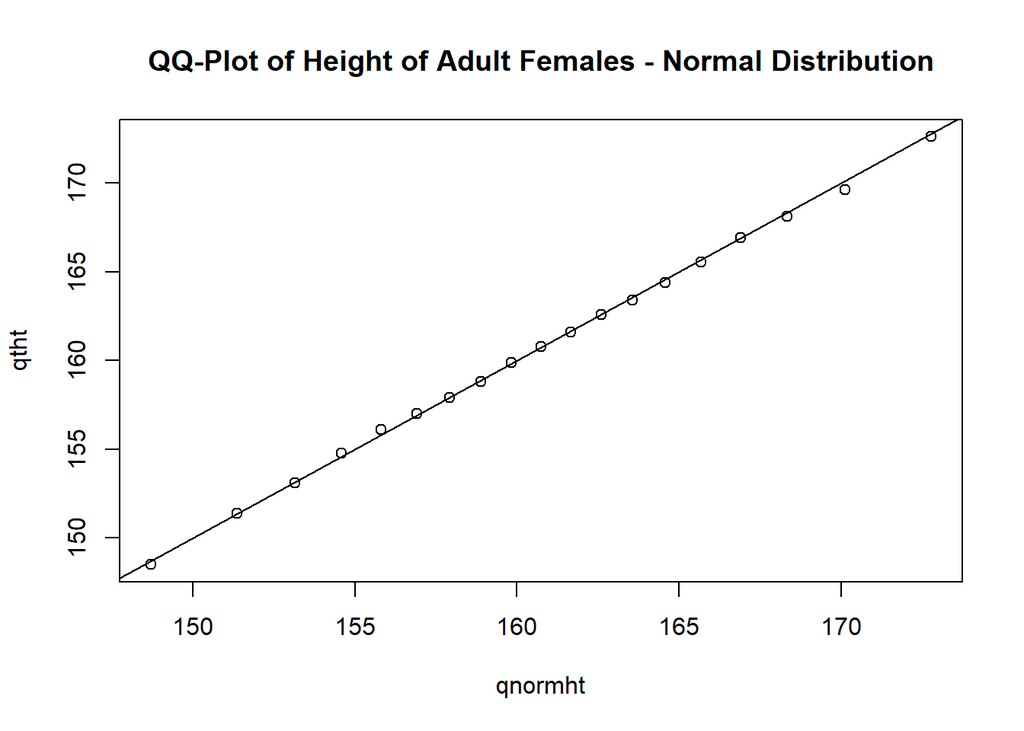

```r
plot(qnormht,qtht, main="QQ-Plot of Height of Adult Females - Normal Distribution")
abline(0,1)
```

```r
#Outputs of Estimated Parameters
meangh
```

```
## [1] 5.7246
```

```r
meanht
```

```
## [1] 160.7419
```

```r
stdgh
```

```
## [1] 1.052246
```

```r
stdht
```

```
## [1] 7.320161
```

Method of Moments using the Normal Distribution seems to be a poor fit for Glycohemoglobin as significant deviations from the ecdf and the histograms are observed in Glycohemoglobin data while it seems to be a decent fit for the Height of Adult Females data as the CDF and the PDF generated by moments look reasonably similar thought it fails to catch the peaks of the histogram in case of the PDF. The QQ plot using the Normal Distribution seems to be a great fit for Height of Adult Females data but a poor fit for the Glycohemoglobin data.

Method of Moments - Weibull Distribution

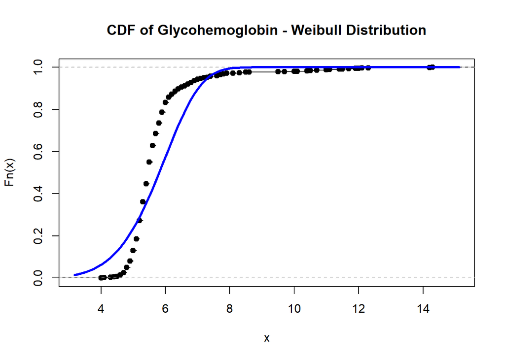

```r
mean_weibull = function(lambda, k){
  lambda*gamma(1+1/k)
}

var_weib = function(lambda, k){
  lambda^2*(gamma(1+2/k)-(gamma(1+1/k))^2)
}

lambda_hat = function(sample_mean, k){
  sample_mean/gamma(1+1/k)
}

var_weib_hat = function(sample_mean, k){
  lambda_hat(sample_mean,k)^2*(gamma(1+2/k)-(gamma(1+1/k))^2)
}

var_weib_hat_optim = function( k, sample_mean,sample_var){
  lambda_hat(sample_mean,k)^2*(gamma(1+2/k)-(gamma(1+1/k))^2)-sample_var
}

mmweib_optimgh = optimize(f=function(x) {abs(var_weib_hat_optim(k=x,
                                                       sample_mean=mean(d1$gh),
                                                       sample_var=var(d1$gh)))},
                  lower=4, upper=100)

mmweib_optimht = optimize(f=function(x) {abs(var_weib_hat_optim(k=x,
                                                       sample_mean=mean(d1$ht),
                                                       sample_var=var(d1$ht)))},
                  lower=4, upper=100)

mmweib_khatgh = mmweib_optimgh$minimum
mmweib_lambdahatgh = lambda_hat(sample_mean=mean(d1$gh), k=mmweib_khatgh)
mmweib_khatht = mmweib_optimht$minimum
mmweib_lambdahatht = lambda_hat(sample_mean=mean(d1$ht), k=mmweib_khatht)

Fghweib <- function(x){
pweibull(x, scale = mmweib_lambdahatgh , shape = mmweib_khatgh)
}

Fhtweib <- function(x){
pweibull(x, scale = mmweib_lambdahatht , shape = mmweib_khatht)
}

plot(ecdf(d1$gh), main = "CDF of Glycohemoglobin - Weibull Distribution")
curve(Fghweib(x), add = TRUE, col = "blue", lwd = 3)
```

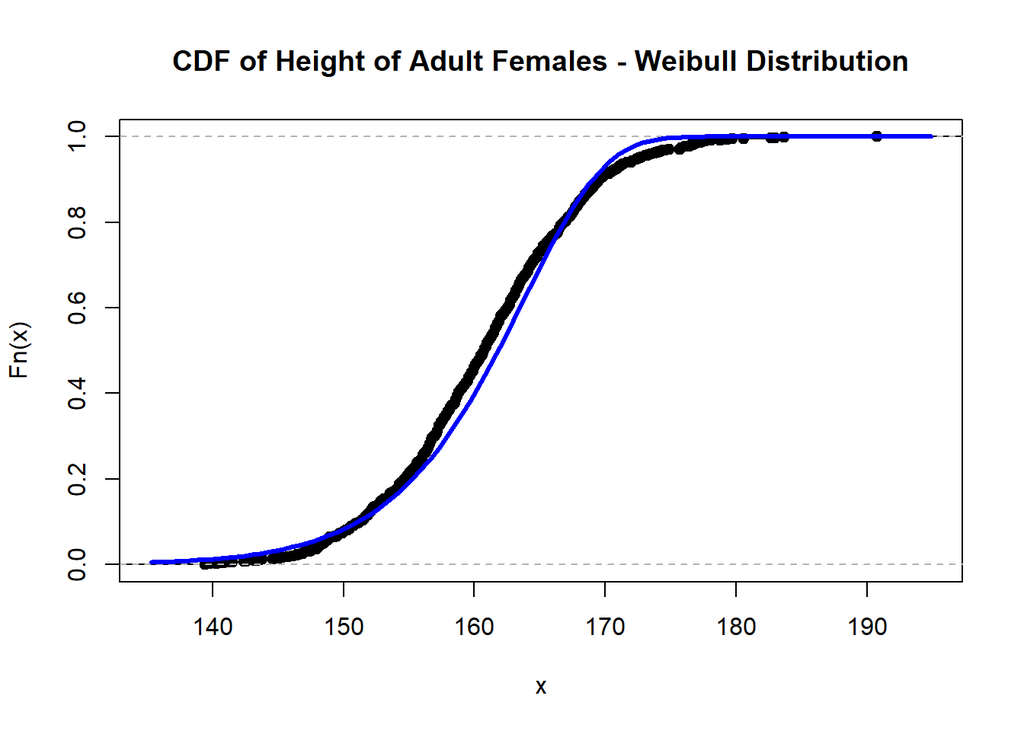

```r
plot(ecdf(d1$ht), main = "CDF of Height of Adult Females - Weibull Distribution")
curve(Fhtweib(x), add = TRUE, col = "blue", lwd = 3)
```

[figure not shown]

```r
fghweib <- function(x){dweibull(x, scale = mmweib_lambdahatgh , shape = mmweib_khatgh)}
fhtweib <- function(x){dweibull(x, scale = mmweib_lambdahatht , shape = mmweib_khatht)}

hist(d1$gh, breaks = 100, freq = FALSE, main = "PDF of Glycohemoglobin - Normal Distribution")
curve(fghweib(x), add = TRUE, col = "blue", lwd = 3)
```

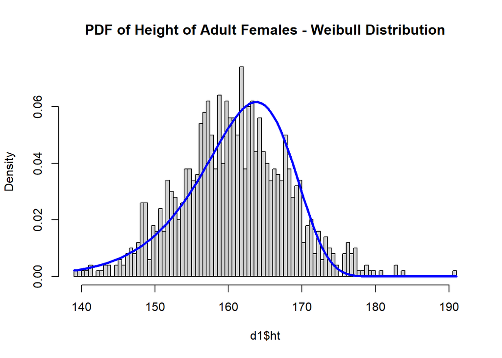

```r
hist(d1$ht, breaks = 100, freq = FALSE, main = "PDF of Height of Adult Females - Weibull Distribution")
curve(fhtweib(x), add = TRUE, col = "blue", lwd = 3)
```

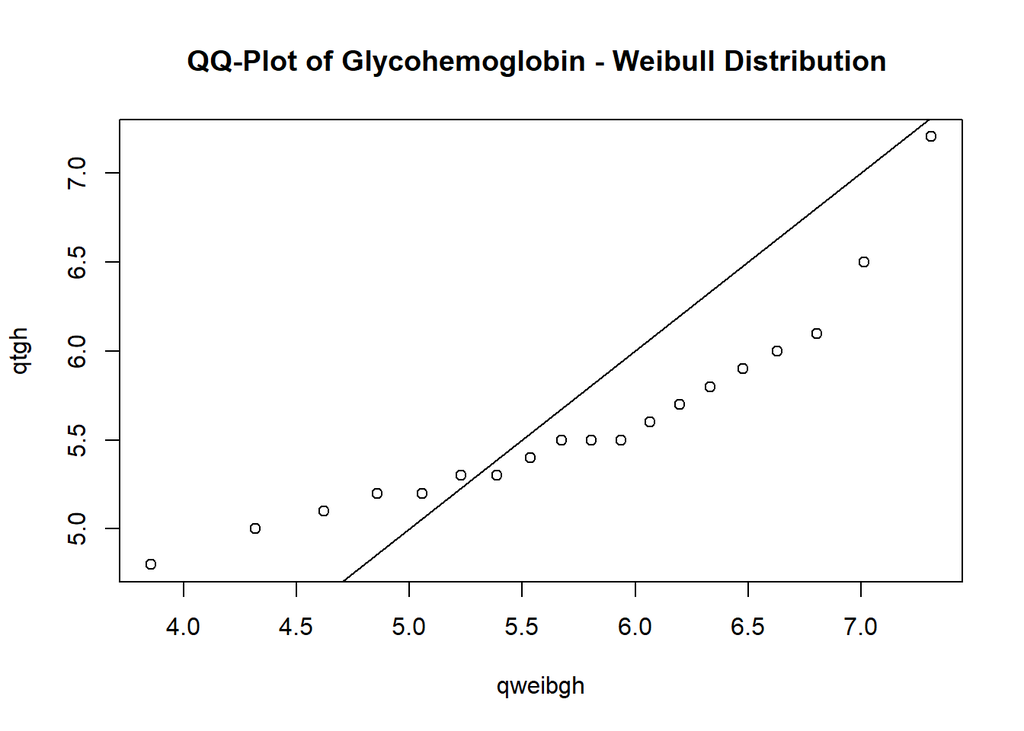

```r
qweibgh <- qweibull(sq, scale = mmweib_lambdahatgh , shape = mmweib_khatgh)
qweibht <- qweibull(sq, scale = mmweib_lambdahatht , shape = mmweib_khatht)
plot(qweibgh,qtgh, main="QQ-Plot of Glycohemoglobin - Weibull Distribution ")
abline(0,1)
```

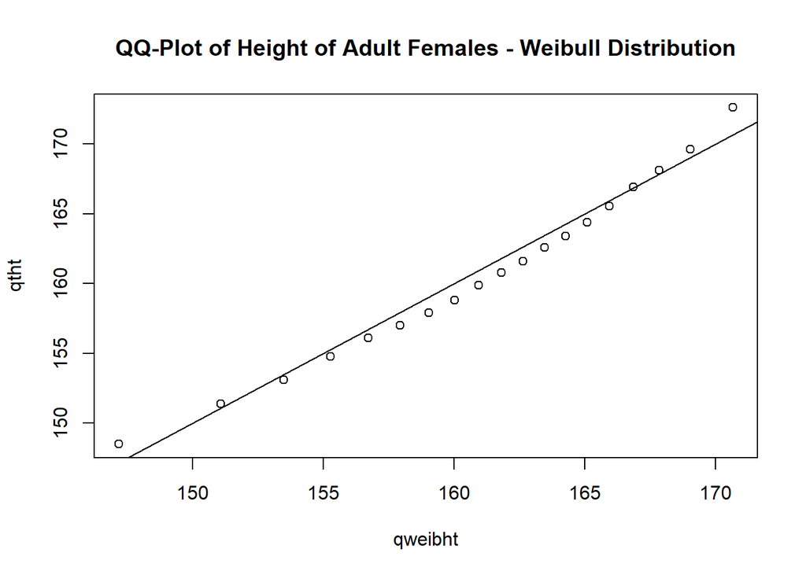

```r
plot(qweibht,qtht, main="QQ-Plot of Height of Adult Females - Weibull Distribution")
abline(0,1)
```

```r
#Outputs of Estimated Parameters
mmweib_khatgh
```

```
## [1] 6.353164
```

```r
mmweib_khatht
```

```
## [1] 27.45939
```

```r
mmweib_lambdahatgh
```

```
## [1] 6.151308
```

```r
mmweib_lambdahatht
```

```
## [1] 163.9807
```

Method of Moments using the Weibull Distribution seems to be a poor fit for Glycohemoglobin as significant deviations from the ecdf and the histograms are observed while it seems to be a somewhat acceptable fit for the Height of Adult Females data as the CDF and the PDF generated by moments look reasonably similar thought it fails to catch the peaks of the histogram in case of the PDF. The QQ plot using the Weibull Distribution seems to be an okay fit for Height of Adult Females data with some deviations but a poor fit for the Glycohemoglobin data.

```r
median(d1$gh)
```

```
## [1] 5.5
```

```r
(mediangammagh <- qgamma(0.5, shape = shape_hatgh, scale = scale_hatgh))
```

```
## [1] 5.660259
```

```r
(mediannormgh <- qnorm(0.5, mean = meangh, sd = stdgh))
```

```
## [1] 5.7246
```

```r
(medianweibgh <- qweibull(0.5, scale = mmweib_lambdahatgh , shape = mmweib_khatgh))
```

```
## [1] 5.806483
```

The above values give the sample median and the estimated median of the Gamma, Normal and Weibull Distribution using the Method of Moments for Glycohemoglobin respectively. They are calculated using the qdist function with p set to 0.5 to get the 50th percentile.

```r
median(d1$ht)
```

```
## [1] 160.8
```

```r
(mediangammaht <- qgamma(0.5, shape = shape_hatht, scale = scale_hatht))
```

```
## [1] 160.6308
```

```r
(mediannormht <- qnorm(0.5, mean = meanht, sd = stdht))
```

```
## [1] 160.7419
```

```r
(medianweibht <- qweibull(0.5, scale = mmweib_lambdahatht , shape = mmweib_khatht))
```

```
## [1] 161.8065
```

The aboe values give the sample median and the estimated median of the Gamma, Normal and Weibull Distribution using the Method of Moments for the Height of Adult Females respectively.

#Maximum Likelihood Maximum Likelihood - Gamma Distribution

```r
gh <- d1$gh
ht <- d1$ht

require(stats4)
```

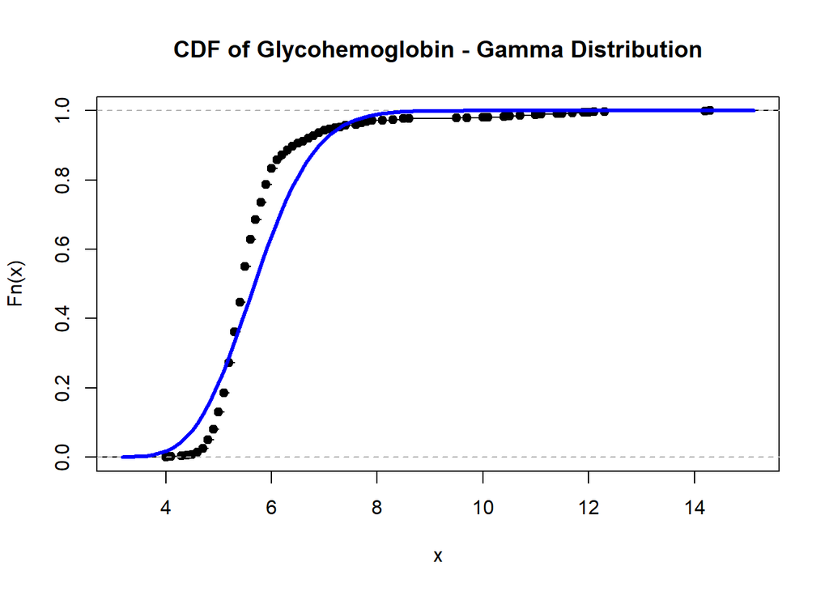

```r
gLLgh <- function(shape, scale){
  fs <- dgamma(
        x = gh
      , scale = scale
      , shape = shape
      , log = TRUE
    )
  -sum(fs)
}

#scale and shape values from method of moment estimates are being used
fitgammagh <- mle(
    gLLgh
  , start = list(scale= 0.193, shape = 29.597)
  , method = "L-BFGS-B"
  , lower = c(0, 0.01)
)

plot(ecdf(gh), main = "CDF of Glycohemoglobin - Gamma Distribution")
curve(
    pgamma(x, shape = coef(fitgammagh)[1], scale = coef(fitgammagh)[2])
  , add = TRUE
  , col = "blue"
  , lwd = 3
)
```

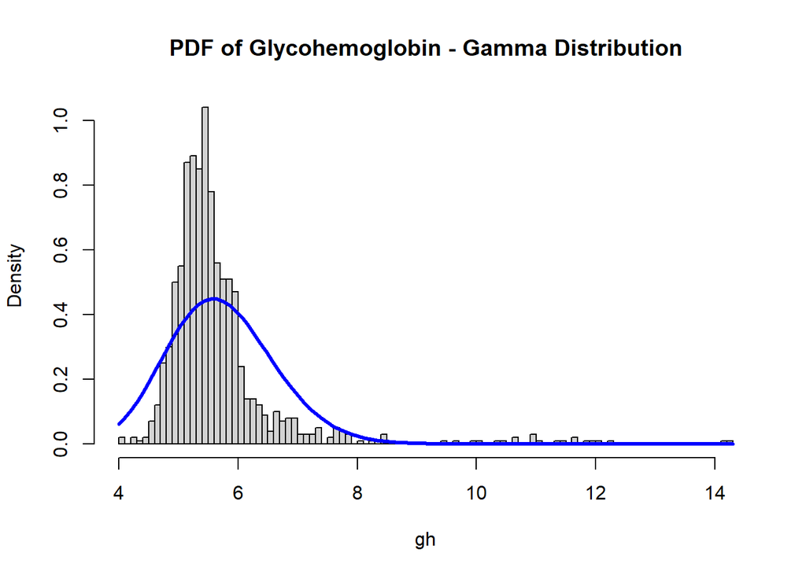

```r
hist(gh, freq = FALSE, breaks = 100, main = "PDF of Glycohemoglobin - Gamma Distribution")
curve(
    dgamma(x, shape=coef(fitgammagh)[1], scale=coef(fitgammagh)[2])
  , add = TRUE
  , col = "blue"
  , lwd = 3
)
```

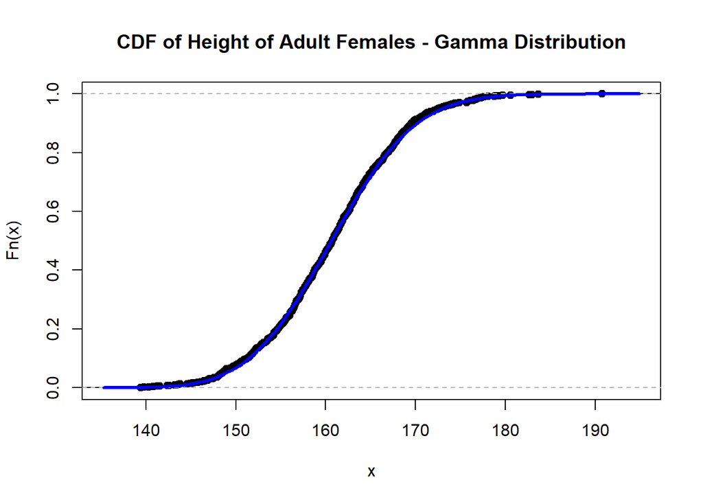

```r
gLLht <- function(scale, shape){
  fs <- dgamma(
        x = ht
      , scale = scale
      , shape = shape
      , log = TRUE
    )
  -sum(fs)
}

fitgammaht <- mle(
    gLLht
  , start = list(scale = 0.333, shape = 482.188)
  , method = "L-BFGS-B"
  , lower = c(0, 0.01)
)

plot(ecdf(ht), main = "CDF of Height of Adult Females - Gamma Distribution")
curve(
    pgamma(x, shape = coef(fitgammaht)[2], scale = coef(fitgammaht)[1])
  , add = TRUE
  , col = "blue"
  , lwd = 3
)
```

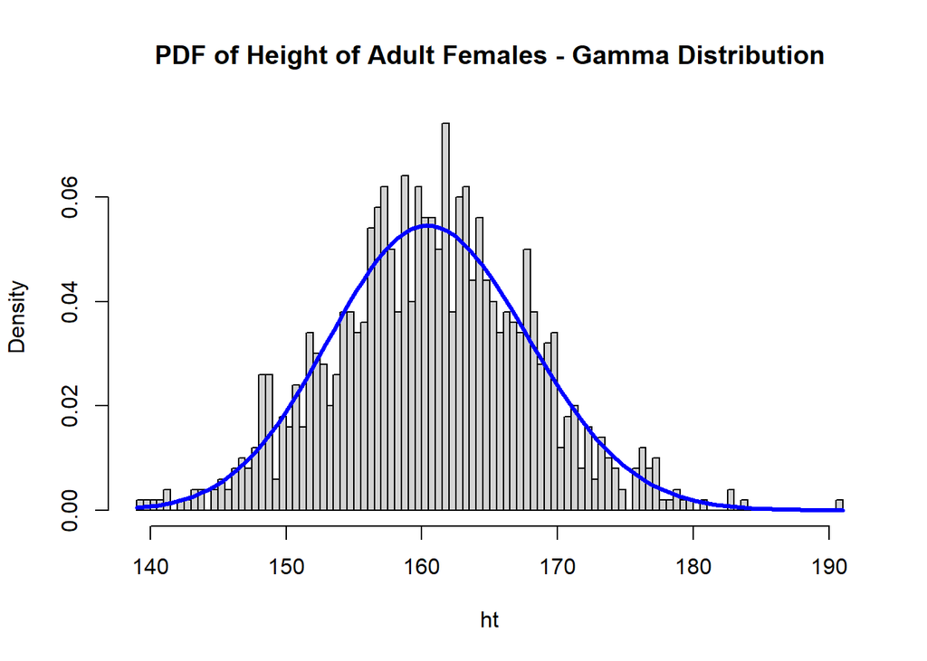

```r
hist(ht, breaks = 100, freq = FALSE, main = "PDF of Height of Adult Females - Gamma Distribution")
curve(
    dgamma(x, shape = coef(fitgammaht)[2], scale = coef(fitgammaht)[1])
  , add = TRUE
  , col = "blue"
  , lwd = 3
)
```

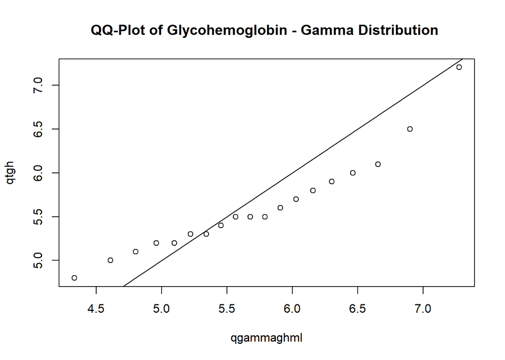

```r
qgammaghml <- qgamma(sq, shape = coef(fitgammagh)[1], scale = coef(fitgammagh)[2])
qgammahtml <- qgamma(sq, shape = coef(fitgammaht)[2], scale = coef(fitgammaht)[1])
plot(qgammaghml,qtgh, main="QQ-Plot of Glycohemoglobin - Gamma Distribution ")
abline(0,1)
```

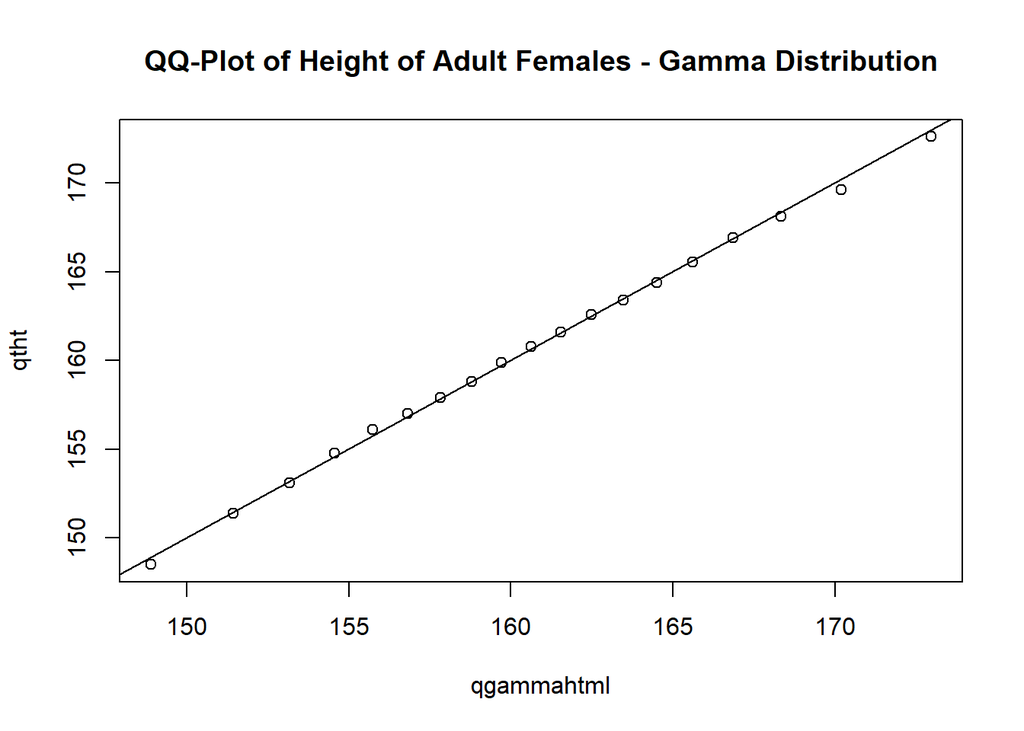

```r
plot(qgammahtml,qtht, main="QQ-Plot of Height of Adult Females - Gamma Distribution")
abline(0,1)
```

```r
#Outputs of Estimated Parameters
coef(fitgammagh)[1]
```

```
##   shape
## 40.7065
```

```r
coef(fitgammagh)[2]
```

```
##     scale
## 0.1406358
```

```r
coef(fitgammaht)[1]
```

```
##     scale
## 0.3333594
```

```r
coef(fitgammaht)[2]
```

```
##   shape
## 482.188
```

Maximum Likelihood - Normal Distribution

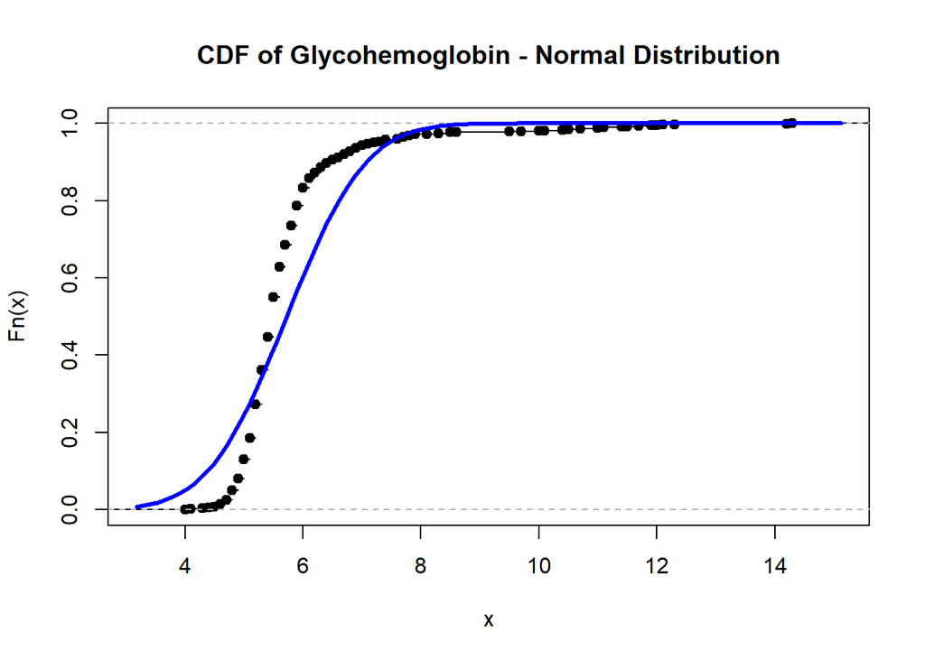

```r
nLLgh <- function(mean, sd){
  fs <- dnorm(
        x = gh
      , mean = mean
      , sd = sd
      , log = TRUE
    )
  -sum(fs)
}

fitnormgh <- mle(
    nLLgh
  , start = list(mean = 1, sd = 1)
  , method = "L-BFGS-B"
  , lower = c(0, 0.01)
)

plot(ecdf(gh), main = "CDF of Glycohemoglobin - Normal Distribution")
curve(
    pnorm(x, coef(fitnormgh)[1], coef(fitnormgh)[2])
  , add = TRUE
  , col = "blue"
  , lwd = 3
)
```

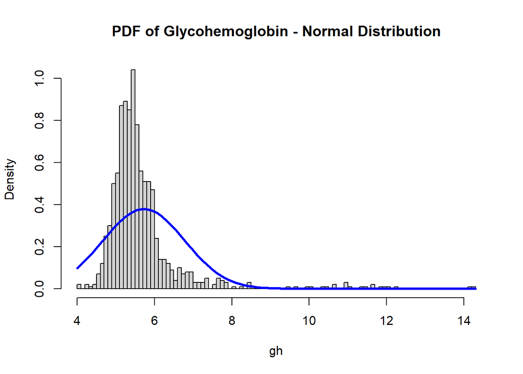

```r
hist(gh, freq = FALSE, breaks = 100, main = "PDF of Glycohemoglobin - Normal Distribution")
curve(
    dnorm(x, coef(fitnormgh)[1], coef(fitnormgh)[2])
  , add = TRUE
  , col = "blue"
  , lwd = 3
)
```

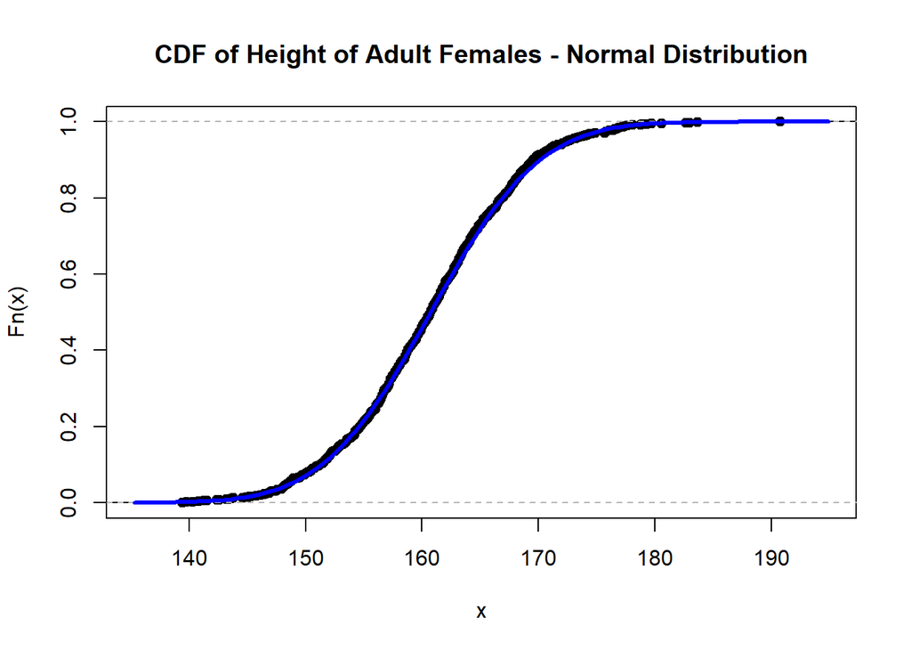

```r
nLLht <- function(mean, sd){
  fs <- dnorm(
        x = ht
      , mean = mean
      , sd = sd
      , log = TRUE
    )
  -sum(fs)
}

fitnormht <- mle(
    nLLht
  , start = list(mean = 1, sd = 1)
  , method = "L-BFGS-B"
  , lower = c(0, 0.01)
)

plot(ecdf(ht), main = "CDF of Height of Adult Females - Normal Distribution")
curve(
    pnorm(x, coef(fitnormht)[1], coef(fitnormht)[2])
  , add = TRUE
  , col = "blue"
  , lwd = 3
)
```

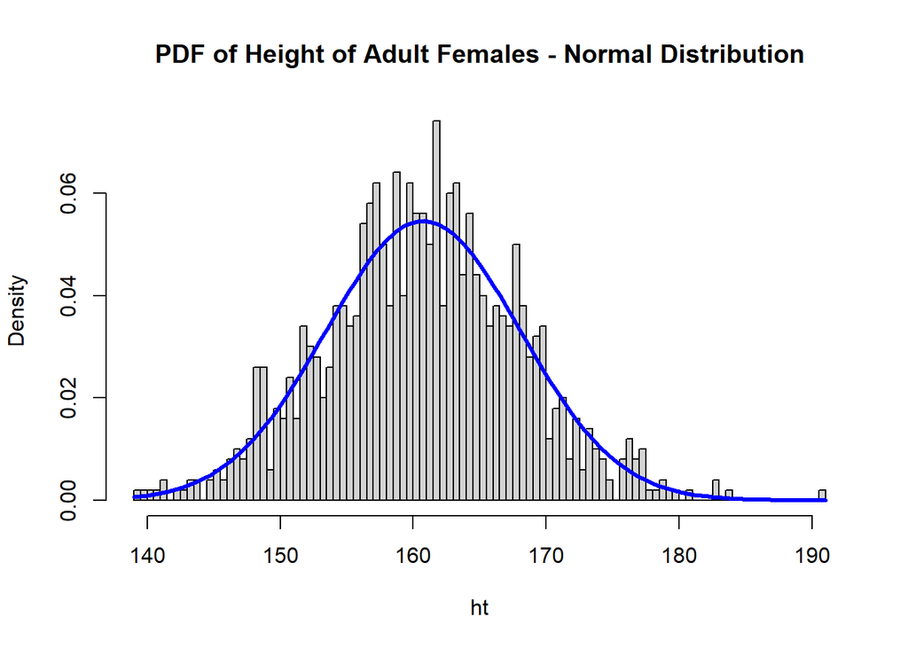

```r
hist(ht, breaks = 100, freq = FALSE, main = "PDF of Height of Adult Females - Normal Distribution")
curve(
    dnorm(x, coef(fitnormht)[1], coef(fitnormht)[2])
  , add = TRUE
  , col = "blue"
  , lwd = 3
)
```

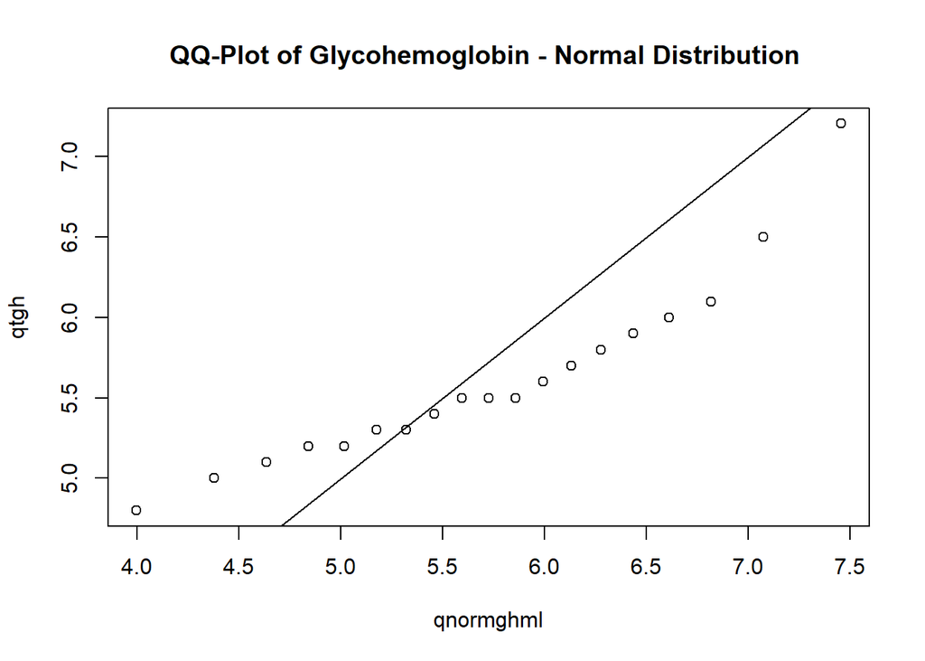

```r
qnormghml <- qnorm(sq, mean = coef(fitnormgh)[1], sd = coef(fitnormgh)[2])
qnormhtml <- qnorm(sq, mean = coef(fitnormht)[1], sd = coef(fitnormht)[2])
plot(qnormghml,qtgh, main="QQ-Plot of Glycohemoglobin - Normal Distribution ")
abline(0,1)
```

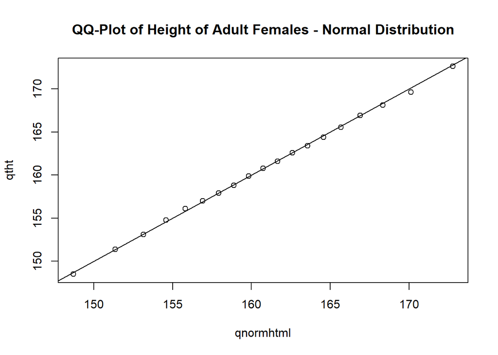

```r
plot(qnormhtml,qtht, main="QQ-Plot of Height of Adult Females - Normal Distribution")
abline(0,1)
```

```r
#Outputs of Estimated Parameters
coef(fitnormgh)[1]
```

```
##   mean
## 5.7246
```

```r
coef(fitnormgh)[2]
```

```
##      sd
## 1.05172
```

```r
coef(fitnormht)[1]
```

```
##     mean
## 160.7419
```

```r
coef(fitnormht)[2]
```

```
##       sd
## 7.316502
```

Maximum Likelihood using the Normal Distribution seems to be a poor fit for Glycohemoglobin as significant deviations from the ecdf and the histograms are observed in Glycohemoglobin data while it seems to be a decent fit for the Height of Adult Females data as the CDF and the PDF generated by moments look reasonably similar thought it fails to catch the peaks of the histogram in case of the PDF. The QQ plot using the Normal Distribution seems to be a great fit for Height of Adult Females data but a poor fit for the Glycohemoglobin data.